# Shortest Paths

Jing Fang and Shihui Ma

# Overview

# Overview

- The shortest path problem is a classic problem in mathematics and computer science with applications in
  - Economics (sequential decision making, analysis of social networks, etc.)
  - Operations research and transportation
  - Robotics and artificial intelligence
  - Telecommunication network design and routing
  - Etc., etc.

# Overview

- For us, the shortest path problem also provides a simple introduction to the logic of dynamic programming, which is one of our key topics

Variations of the methods we discuss are used millions of times every day, in applications such as Google Maps

# Outline of the Problem

# Outline of the Problem

- The shortest path problem is one of finding how to traverse a graph from one specified node to another at minimum cost
- Consider the following graph

# Outline of the Problem

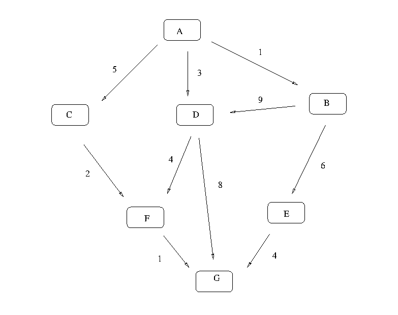

# Outline of the Problem

- We wish to travel from node (vertex) A to node G at minimum cost
  - Arrows (edges) indicate the movements we can take
  - Numbers next to edges indicate the cost of traveling that edge
- Possible interpretations of the graph include
  - Minimum cost for supplier to reach a destination
  - Routing of packets on the internet (minimize time)
  - Etc., etc.
- For this simple graph, a quick scan of the edges shows that the optimal paths are
  - A, C, F, G at cost 8
  - A, D, F, G at cost 8

# Finding Least-Cost Paths

# Finding Least-Cost Paths

- For large graphs we need a systematic solution
- Let $J(v)$ denote the minimum cost-to-go from node $v$, understood as the total cost from v if we take the best route
- Suppose that we know $J(v)$ for each node v, as shown below for the graph from the preceding example

# Finding Least-Cost Paths

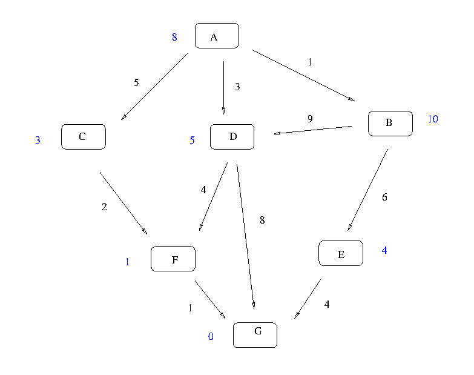

# Finding Least-Cost Paths

- Note that $J(G)=0$
- Intuitively, the best path can now be found as follows
  - Start at $A$
  - From node $v$, move to any node that solves
    $$\min_{w\in F_v}\{c(v,w)+J(w)\}$$
    where
  - $F_v$ is the set of nodes that can be reached from $v$ in one step
  - $c(v,w)$ is the cost of traveling from $v$ to $w$
- Hence, if we know the function $J$, then finding the best path is almost trivial

# Finding Least-Cost Paths

- But how to find $J$?
- Some thought will convince you that, for every node $v$, the function $J$ satisfies
  $$J(v)=\min_{w\in F_v}\{c(v,w)+J(w)\}$$
- This is known as the Bellman equation
  - That is, $J$ is the solution to the Bellman equation
  - There are algorithms for computing the minimum cost-to-go function $J$

# Solving for $J$

# Solving for $J$

- The standard algorithm for finding $J$ is to start with
  $$J_0(v)=M \text{ if } v\neq\text{destination, else }J_0(v)=0$$
  where M is some large number
- Now we use the following algorithm
  1. Set $n=0$
  2. Set $J_{n+1}(v)=\min_{w\in F_v}\{c(v,w)+J_n(w)\}$ for all $v$
  3. If $J_{n+1}$ and $J_n$ are not equal then increment $n$, go to 2
- In general, this sequence converges to $J$—the proof is omitted

# Exercises

# Exercises 1